# Bush stone-curlew behaviour and performance analyes

Shoshana Rapley

2024-07-30

```r
knitr::opts_chunk$set(echo = TRUE)

# Load packages
pacman::p_load(beepr, contsurvplot, ggpubr, janitor, MuMIn, performance, readxl, sjPlot, survival, survminer, tidyverse)

# Bird list excluding Daisy (returned to captivity) & Star (disease fate)
birds <- c("Briar", "Nutmeg", "Aurora", "Robin",
           "Iona", "Sage", "Koda", "Brook", "Clover",
           "Prem", "Rove", "Valentine", "Marmalade", "Wobbles")
```

# Introduction

This Markdown documents analyses done as part of paper ‘captive behaviour predicts translocation performance in bush stone-curlews’, a chapter of my doctoral studies.

The aim of this study is to test whether we can predict post-release performance using pre-release assays in translocated bush stone-curlews. If true, we might be able screen for suitable release candidates in future translocations.

In this study we translocated 16 bush stone-curlews into the Mt Rothwell fenced sancatuary from the Mt Rothwell breeding colony. They were released in October 2022 to January 2023 across three release groups. This was the pilot release at the site (i.e., no conspecifics prior to the translocation and a high degree of risk and uncertainty), which is why we released in a ‘drip feed’ manner over the Summer of 2022/23.

Two individuals were excluded from analyses. Daisy was returned to captivity after two days due to risky behaviour (hanging around the buildings in a high traffic area). Star died of gastroenteritis shortly after release and so her fate was not linked to behaviour.

# Predictors

We undertook pre-release assays prior to release of the birds. The pre-release assays were:

1. Latency to reach food
2. Handling response (in-hand)
3. Filmed behaviour

Predictors A and C were filmed in their home aviaries with trail cameras. Predictor B was scored during routine handling.

## Latency

Latency to reach food was defined as how long it took each bird, in seconds, to reach a plate of food provided as part of their normal husbandry. It was measured from when the plate was placed on the ground until the bird took the first mouthful.

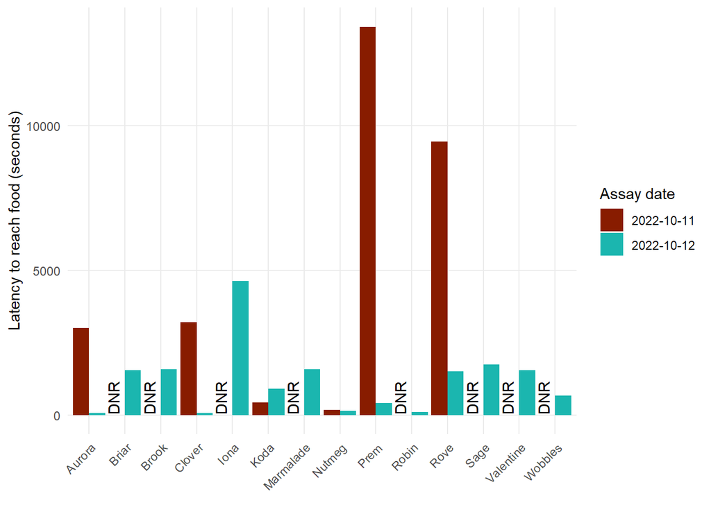

```r
# Read in and clean up latency assay data
latency <- read_excel("Input/bsc assay data.xlsx", sheet =3) %>%
  clean_names() %>%
  # Select study birds
  filter(bird %in% birds) %>%
  # Filter to assay dates
  filter(date %in% c("2022-10-12", "2022-10-11")) %>%
  dplyr::select(c("date", "bird", "reach", "latency_s")) %>%
  # Convert yes/no to 1/0
  mutate(reach = ifelse(reach == "Yes", 1, 0)) %>%
  rename(latency = latency_s) %>%
  # Add column for plotting 'did not reach'
  mutate(label = ifelse(is.na(latency), "DNR", ""))

# Plot latency by bird
ggplot(latency) +
  geom_bar(aes(bird, latency, fill = as.character(date)),
           position = "dodge", stat = "identity")+
  geom_text(aes(y=600, x= bird, label = label), angle = 90, vjust = -0.5)+
  theme(panel.grid.major = element_blank(), panel.grid.minor = element_blank())+
  labs(x= element_blank(), y = "Latency to reach food (seconds)")+
  scale_x_discrete(guide = guide_axis(angle = 45)) +
  scale_fill_manual(values = c("#881C00FF","#1BB6AFFF"), name = "Assay date")+
  theme_minimal()+
  theme(panel.grid.minor = element_blank())
```

We need to account for repeat measures but due to low sample size we cannot use bird as a random factor (model convergence issues when tested). So instead, we are going to use the mean latency. The birds didn’t reach the food on one third of occasions, but all birds reached the food at least once (out of two trials).

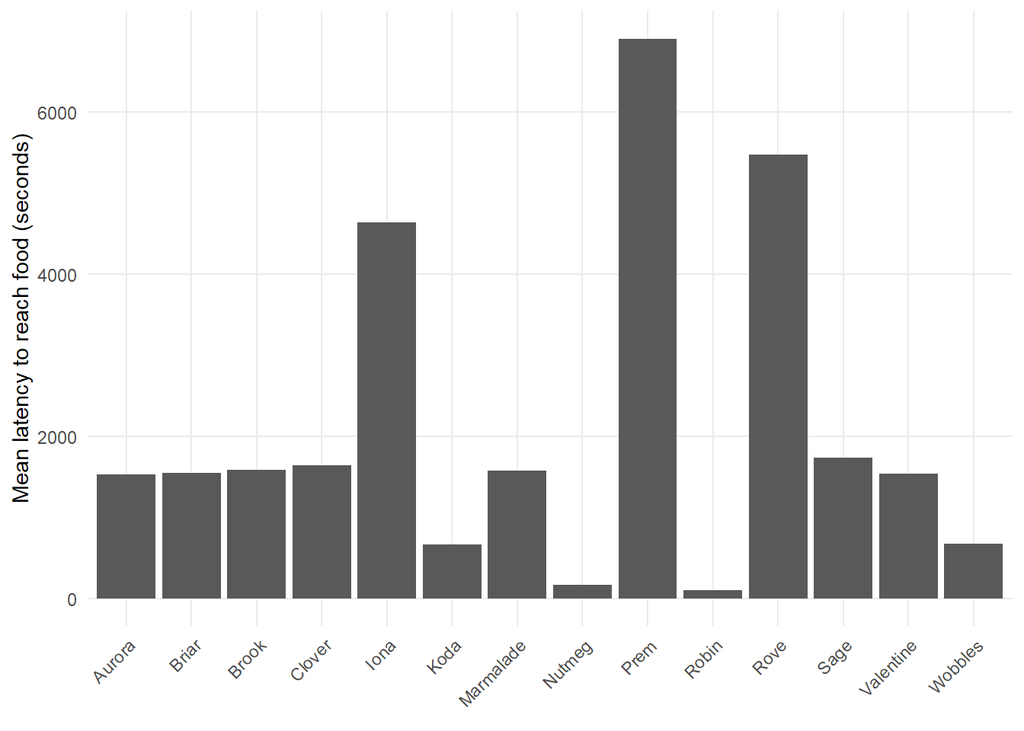

```r
# Calculate mean latency by bird
mlatency <- latency %>%
  na.omit() %>%
  group_by(bird) %>%
  summarise(latency = mean(latency))

# Plot mean latency by bird
ggplot(mlatency) +
  geom_bar(aes(bird, latency), position = "dodge", stat = "identity")+
  theme(panel.grid.major = element_blank(), panel.grid.minor = element_blank())+
  labs(x= element_blank(), y = "Mean latency to reach food (seconds)")+
  scale_x_discrete(guide = guide_axis(angle = 45)) +
  scale_fill_manual(values = c("#881C00FF","#1BB6AFFF"), name = "Assay date")+
  theme_minimal()+
  theme(panel.grid.minor = element_blank())
```

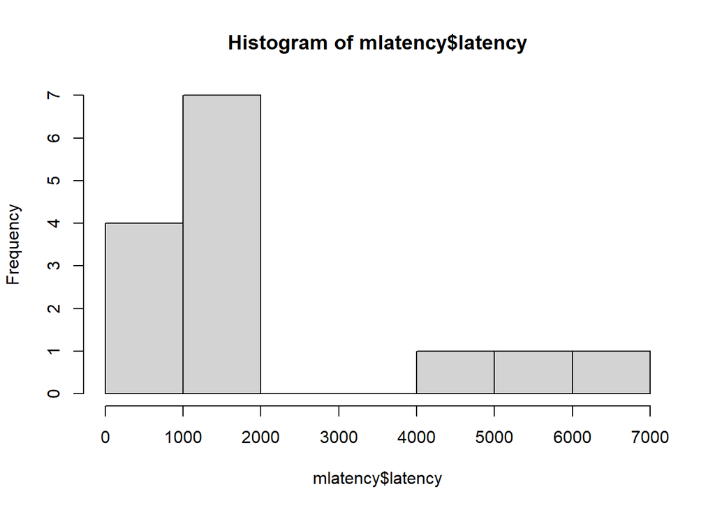

```r
# Check the distribution of mean latency
hist(mlatency$latency)
```

```r
shapiro.test(mlatency$latency)
```

```
##
##  Shapiro-Wilk normality test
##
## data:  mlatency$latency
## W = 0.77933, p-value = 0.002802
```

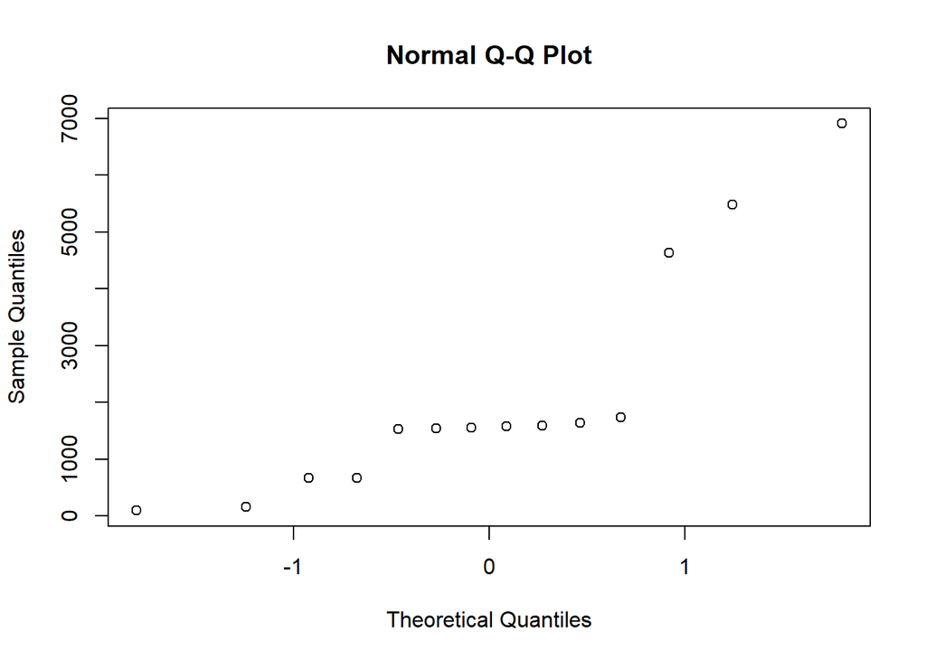

```r
qqnorm(mlatency$latency)
```

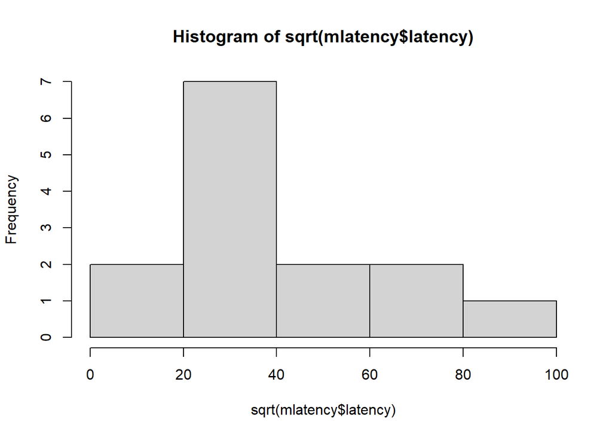

```r
# Transform mean latency
hist(sqrt(mlatency$latency))
```

```r
shapiro.test(sqrt(mlatency$latency))
```

```
##
##  Shapiro-Wilk normality test
##
## data:  sqrt(mlatency$latency)
## W = 0.89486, p-value = 0.095
```

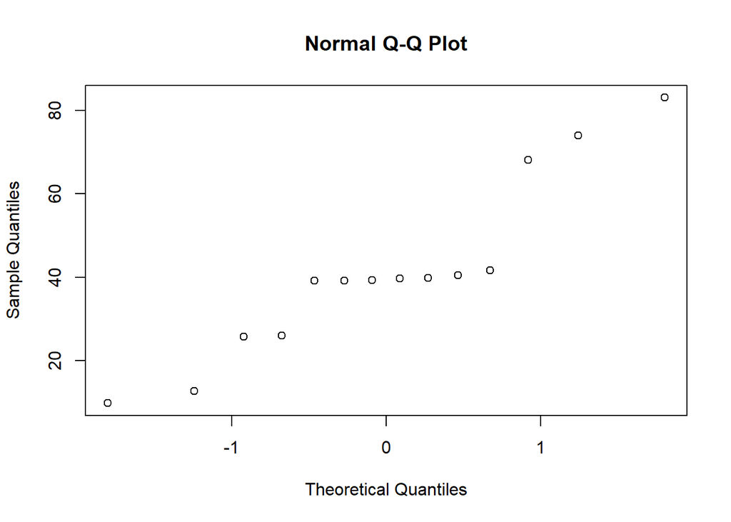

```r
qqnorm(sqrt(mlatency$latency))
```

## Handling response

Handling response was assigned during processing, and is an ordinal variable on a scale of 1:3:

1. Calm/still/log-pose
2. Moderate/slight kicking or struggling/soft calling or beak clacking
3. Extreme/upset/shrieking/growling

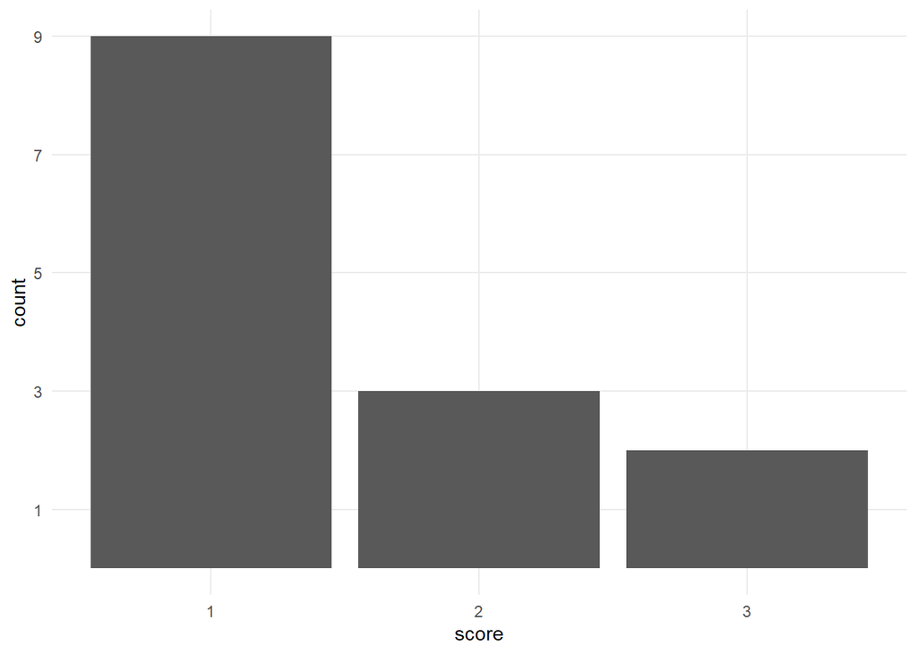

```r
# Read in handling data
handling <- read_excel("Input/bsc assay data.xlsx", sheet = 7) %>%
  clean_names() %>%
  rename(bird = identity) %>%
  # Filter to study birds
  filter(bird %in% birds) %>%
  # Filter to assay dates
  filter(date %in% c("2022-10-20")) %>%
  # Drop unneeded columns
  dplyr::select(c(bird, score))

# Plot frequency of handling scores
ggplot(handling)+
  geom_bar(aes(score))+
  scale_y_continuous(breaks =c(1,3,5,7,9))+
  theme_minimal()+
  theme(panel.grid.minor = element_blank())
```

Most birds (64%) had a handling score of 1, with 21% a score of 2 and just two individuals (14%) with a score of 3.

As a side note, where we have repeat measures (i.e., taken post-release- but these aren’t documented here) the handling response stays the same; however, for now we are just interested in whether the pre-release assay values predict other post-release behaviours.

## Behaviour

Birds were filmed in their aviaries between 12pm-4pm. For every film recorded (activated by the infrared sensor on the trail camera) we encoded each second of behaviour for each bird. We calculated the the proportion of time spent in alert behaviours (considered mutually exclusive from ‘relaxed’ behaviours).

*Alert behaviours* were defined as:

- Alertness: standing but not relaxed, often startled into this pose from a more relaxed posture. May have a stiffer pose, holding neck extended or forward. May have flattened the feathers against the body.
- Postured walk: walking with the neck stiffly extended parallel wit the ground. Feathers either fluffed up (held erect) or slimmed against body, as opposed to held loosely.
- Head-bobbing: a rapid up/down movement of the head; used to communicate unease.
- Head-tilting: craning the head to the side to look above and around; possibly to check for danger (can be done in tandem with head-bobbing).
- Tail-wagging: a rapid side/side shake of the tail; used to communicate unease.
- Defensive display: holding the wings outstretched; often wings are rapidly extended which gives the impression of a black and white ‘flash’ of plumage.

*Relaxed behaviours* were defined as:

- Preening: actively cleaning self (i.e., running the beak along the feathers, rearranging plumage), or scratching (e.g. the face with the toes), or stretching (e.g. extending the leg and wing).
- Fluffing: a rapid erection and flattening of the feathers, often accompanied by a body and head shake. Often preceded by preening.
- Standing: relaxed pose (in the absence of vigilant behaviours as defined above), feathers loose or lightly fluffed (as opposed to erect or flat against the body).
- Walking: stepping forward (in the absence of vigilant behaviours as defined above).
- sitting: either on tibiotarsus or fully on the ground; includes sleeping.
- Eating: engaged in looking at, carrying, pecking, picking up, swallowing or breaking up food (or non food items that are being tested e.g. leaves). Can rapidly (second by second) change between eating and alertness.
- Calling: calling as part of group crescendo with “werloo” song (as opposed to short contact calls while doing other beahviours such as sitting or standing)

Here we read in the video assay data and calculate the time spent vigilant as a proportion of whole time. Some videos have sections where the bird is out of frame (noted in ethogram as ‘Z’), which are excluded from the time allocation analysis.

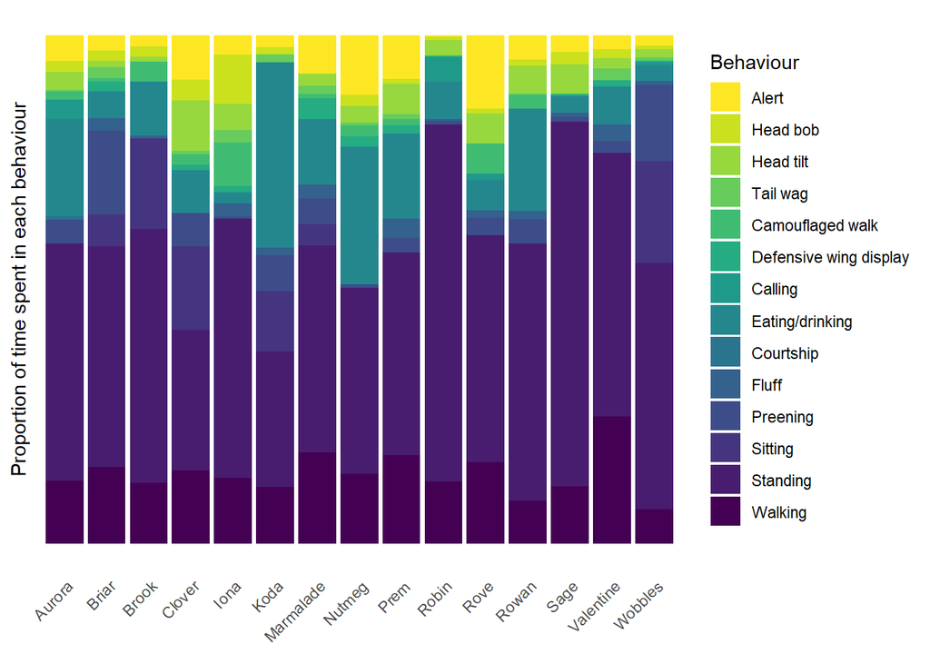

```r
# Ethogram
eth <- matrix(c("A", "Alert",
                "C", "Calling",
                "D", "Defensive wing display",
                "E", "Eating/drinking",
                "F", "Fluff",
                "HB", "Head bob",
                "HT", "Head tilt",
                "I", "Sitting",
                "N", "Camouflaged walk",
                "O", "Courtship",
                "P", "Preening",
                "S", "Standing",
                "W", "Walking",
                "TW", "Tail wag",
                "Z", "Out of frame"),
              ncol = 2, byrow = TRUE) %>%
  as.data.frame() %>%
  rename(code = V1,
         Behaviour = V2)

# Assign plotting order of behaviours
order <- c("Alert", "Head bob", "Head tilt", "Tail wag", "Camouflaged walk",
           "Defensive wing display", "Calling", "Eating/drinking", "Courtship",
           "Fluff", "Preening", "Sitting", "Standing", "Walking", "Out of frame")

# Read in and tidy up video assays
behaviour <- read_excel("Input/bsc assay data.xlsx", sheet =4) %>%
  clean_names() %>%
  # Drop metadata columns
  dplyr::select(-c("clip", "note")) %>%
  # Convert from wide to long
  pivot_longer(3:61, names_to = "second", values_to = "code") %>%
  # Convert seconds into numeric
  mutate(second = as.numeric(str_remove(second, "x"))) %>%
  # Drop instances of out of frame
  filter(!code == "Z") %>%
  # Lump all variations of head tilt
  mutate(code = ifelse(code %in% c("HBT", "HTB", "HTW"), "HT", code)) %>%
  # Add behaviour descriptions from ethogram
  left_join(eth) %>%
  # Turn behaviour into a factor to assign order for plotting
  mutate(Behaviour = factor(Behaviour, levels = order)) %>%
  # Assign vigilance to 1 and not to 0
  mutate(vigilant = ifelse(code %in%
                             c("A", "D", "HB", "HT", "TW", "N"), 1, 0)) %>%
  # Drop lines without recordings (primarily for Prem and Rove who had 10 second clips)
  na.omit()
# Plot proportion of time spent in each behaviour per bird
ggplot(behaviour) +
  geom_bar(aes(x= bird, fill = Behaviour), position = "fill")+
  labs(x= element_blank(),
       y = "Proportion of time spent in each behaviour")+
  scale_x_discrete(guide = guide_axis(angle = 45)) +
  theme_minimal()+
  theme(panel.grid.major = element_blank(),
        panel.grid.minor = element_blank(),
        axis.text.y = element_blank())+
  scale_fill_viridis_d(direction = -1)
```

```r
# Calculate proportion of time spent in each behaviour and a summed 'alert' metric
time <- count(behaviour, bird) %>%
  rename(total = n)
prop_behav <- count(behaviour, bird, code) %>%
  left_join(time) %>%
  # Divide count of behaviour by total time for %
  mutate(prop = n/total) %>%
  dplyr::select(-c(n, total)) %>%
  # Pivot wider, one column per behaviour
  pivot_wider(names_from = code, values_from = prop) %>%
  # Replace NAs for behaviour with zeroes
  replace(is.na(.), 0) %>%
  # Add column for summed 'alert' measure
  mutate(alert = A + HB + HT + TW + N + D)
```

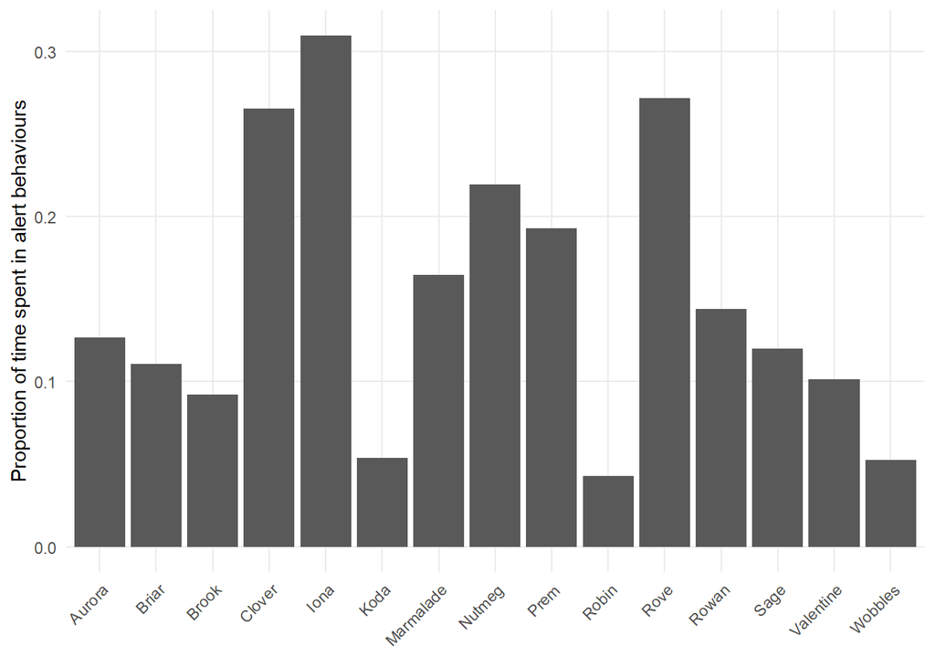

```r
# Plot time spent alert
ggplot(prop_behav) +
  geom_bar(aes(x= bird, y= alert), position = "dodge", stat = "identity")+
  labs(x= element_blank(),
       y = "Proportion of time spent in alert behaviours")+
  scale_x_discrete(guide = guide_axis(angle = 45)) +
  theme_minimal()+
  theme(panel.grid.minor = element_blank())
```

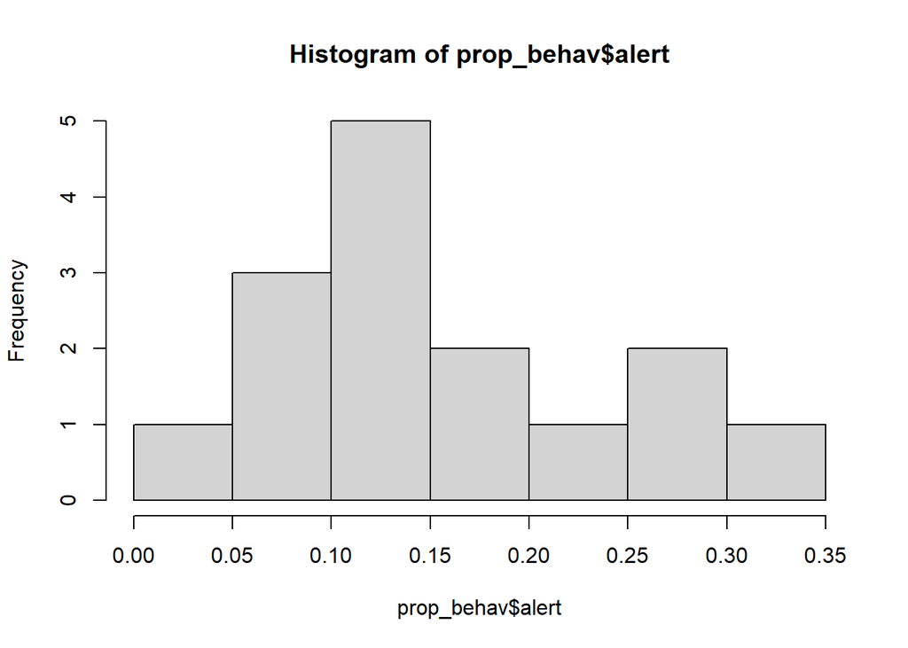

```r
# Check distribution of behaviours
hist(prop_behav$alert)
```

```r
# Summarise allocation of behaviours
prop_behav_sum <- prop_behav %>%
  summarise(across(where(is.numeric),list(mean = mean, sd = sd))) %>%
  pivot_longer(1:30)
```

Interestingly, the amount of time spent ‘alert’ (yellows and greens) seems (visually at least) inversely related to the amount of time spent eating (aqua), rather than cutting in to the time spent resting (purples).

The ‘alert’ metric is close to normally distributed.

## Traits

I included some non-behavioural trait predictors to compare with the assays predictions. These included life-history and morphological traits.

```r
# Read in additional bird metadata
meta <- read_excel("Input/bsc assay data.xlsx", sheet = 8) %>%
  clean_names() %>%
  rename(bird = individual) %>%
  select(c(bird, sex))

# And pre-release weights
weights <- read_excel("Input/bsc assay data.xlsx", sheet = 9) %>%
  clean_names() %>%
  select(c(identity, weight, condition)) %>%
  rename(bird = identity)

# And morphometrics
traits <- read_excel("Input/bsc assay data.xlsx", sheet = 10) %>%
  clean_names()  %>%
  select(c(identity, wing, tail, tarsus)) %>%
  rename(bird = identity) %>%
  filter(bird %in% birds) %>%
  # Combine all traits data
  left_join(meta) %>%
  left_join(weights)
# Summary of weights
weight_sum <- traits %>%
  group_by(sex) %>%
  summarise(weight_mean = mean(weight),
            weight_sd = sd(weight))
```

Out of curiosity, I want to know whether the traits are correlated.

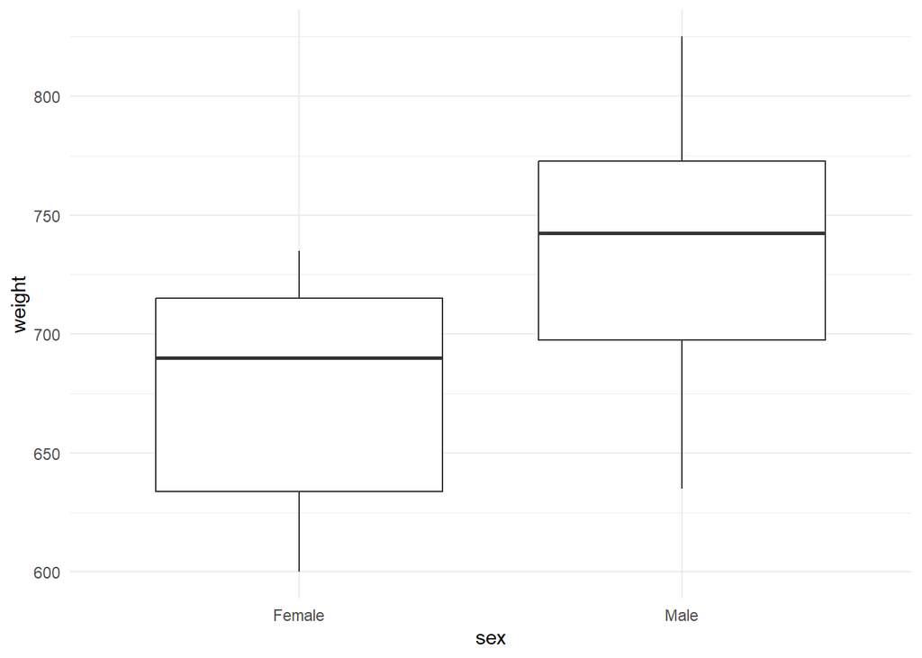

```r
# Weight by sex
ggplot(traits, aes(x = sex, y = weight))+
  geom_boxplot()+
  theme_minimal()
```

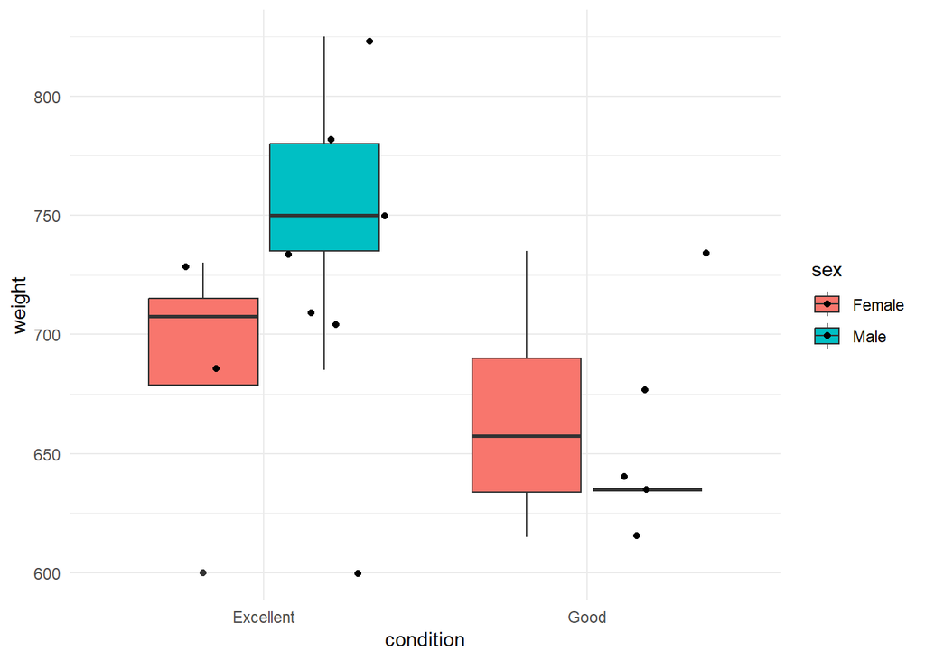

```r
# Weight and condition by sex
ggplot(traits, aes(x= condition, y= weight, fill = sex))+
  geom_boxplot()+
  geom_jitter()+
  theme_minimal()
```

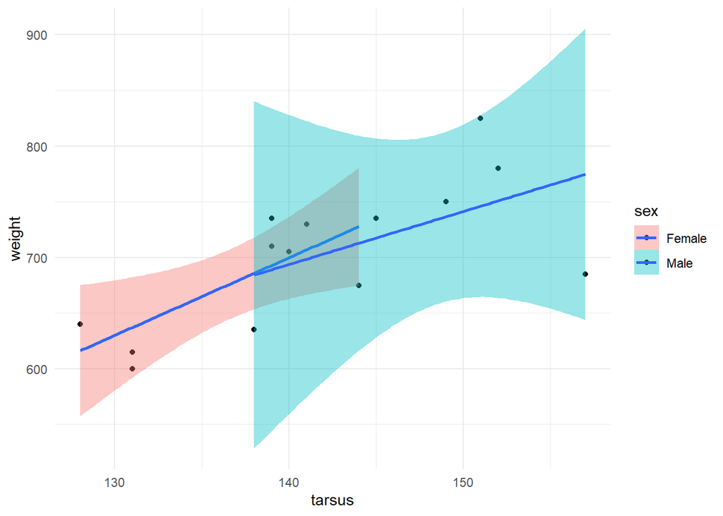

```r
# Weight and tarsus by sex
ggplot(traits, aes(x= tarsus, y= weight, fill = sex))+
  geom_point()+
  geom_smooth(method = "lm")+
  theme_minimal()
```

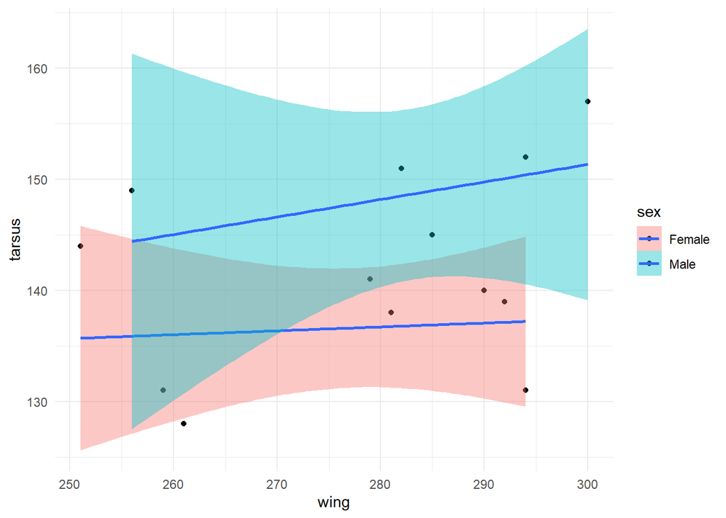

```r
# Wind chord and tarsus by sex
ggplot(traits, aes(x= wing, y= tarsus, fill = sex))+
  geom_point()+
  geom_smooth(method = "lm")+
  theme_minimal()
```

1. Males weigh more than females. Weight in the ‘good’ condition score varies more for females compared to males.
2. Females have in general a smaller weight:tarsus ratio than males, but with sex overlap.
3. Males have a larger tarsus than females but wing lenght only differs at the extremes.

I didn’t end up using the morphometric data in the models due to convergence issues with low sample sizes.

# Responses

We assessed survival in three ways:

- survival to 90-days post-release (yes/no; binary)
- survival to 1-year post-release (yes/no; binary)
- persistence (how many days survived; continuous)

We tested survival to both 90-days and 1-year post-release becasue we wanted to know whether the time period of monitoring impacted the strength of prediction. We chose 90-days because this was the typical tracking duration in previous bush stone-curlew translocation when tracking was done with VHF (which was at Mulligans Flat in 2014-2016).

```r
# Read in survival data
survival <- read.csv("Input/survival.csv") %>%
  clean_names() %>%
  rename(bird = identity) %>%
  filter(bird %in% birds) %>%
  # Limit persistence value to minimum common tracked time of 360
  mutate(persist = ifelse(persist>360, 360, persist)) %>%
  # Convert true and false to 0 and 1
  mutate(to_90 = ifelse(to_90 == FALSE, 0, 1),
         to_360 = ifelse(to_360 == FALSE, 0, 1)) %>%
# Drop unneeded columns
  dplyr::select(c(bird, persist, to_90, to_360))

# Combine survival with all predictors
data <- left_join(survival, mlatency) %>%
  left_join(handling) %>%
  left_join(prop_behav) %>%
  left_join(traits) %>%
  # Drop un-needed behaviour columns
  dplyr::select(-c(A, C, E, F, HB, HT, N, O, P, S, TW, W, D, I))
# Write table to file
write.csv(data, row.names = FALSE, "data_table.csv")
```

# Analyses

## Binary survival

First I take a hypothesis driven approach to looking at the behaviours and traits, to see which predict survival to 90 days and 1 year. I expect to see a difference in which predict survival for each time period, and I expect weight and food to be more important in the short term. I don’t expect to see a difference in traits other than pre-release weight.

### m1 Alert behaviour and survival

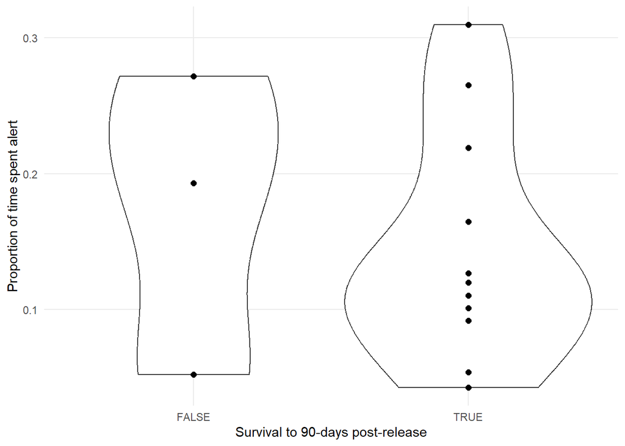

```r
# m1a: Does proportion of time spent alert predict survival to 90 days?
## Violin plot
ggplot(data, aes(x= to_90, y = alert, group=to_90))+
  geom_violin()+
  geom_point(size = 2)+
  labs(x= "Survival to 90-days post-release",
       y = "Proportion of time spent alert")+
  theme_minimal()+
  theme(panel.grid.minor = element_blank())+
  scale_x_continuous(breaks = c(0,1), labels = c(FALSE, TRUE))
```

```r
## Logistic regression with binomial family
m1a <- glm(to_90 ~ scale(alert),
           data = data,
           family = binomial())

summary(m1a)
```

```
##
## Call:
## glm(formula = to_90 ~ scale(alert), family = binomial(), data = data)
##
## Coefficients:
##              Estimate Std. Error z value Pr(>|z|)
## (Intercept)    1.3258     0.6660   1.991   0.0465 *
## scale(alert)  -0.3173     0.6658  -0.477   0.6336
## ---
## Signif. codes:  0 '***' 0.001 '**' 0.01 '*' 0.05 '.' 0.1 ' ' 1
##
## (Dispersion parameter for binomial family taken to be 1)
##
##     Null deviance: 14.548  on 13  degrees of freedom
## Residual deviance: 14.321  on 12  degrees of freedom
## AIC: 18.321
##
## Number of Fisher Scoring iterations: 4
```

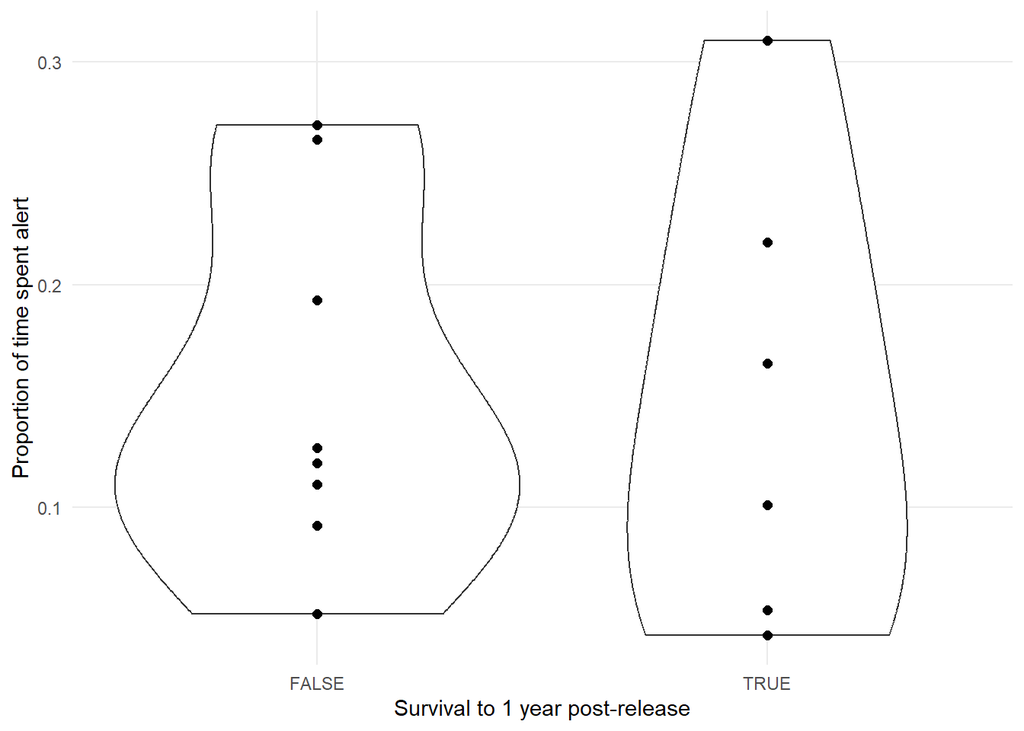

```r
# m1b: Does proportion of time spent alert predict survival to 1 year?
## Violin plot
ggplot(data, aes(x= to_360, y = alert, group=to_360))+
  geom_violin()+
  geom_point(size = 2)+
  labs(x= "Survival to 1 year post-release",
       y = "Proportion of time spent alert")+
  theme_minimal()+
  theme(panel.grid.minor = element_blank())+
  scale_x_continuous(breaks = c(0,1), labels = c(FALSE, TRUE))
```

```r
## Logistic regression with binomial family
m1b <- glm(to_360 ~ scale(alert),
           data = data,
           family = binomial())

summary(m1b)
```

```
##
## Call:
## glm(formula = to_360 ~ scale(alert), family = binomial(), data = data)
##
## Coefficients:
##              Estimate Std. Error z value Pr(>|z|)
## (Intercept)  -0.28798    0.54035  -0.533    0.594
## scale(alert) -0.06611    0.56218  -0.118    0.906
##
## (Dispersion parameter for binomial family taken to be 1)
##
##     Null deviance: 19.121  on 13  degrees of freedom
## Residual deviance: 19.108  on 12  degrees of freedom
## AIC: 23.108
##
## Number of Fisher Scoring iterations: 4
```

### m2 Latency and survival

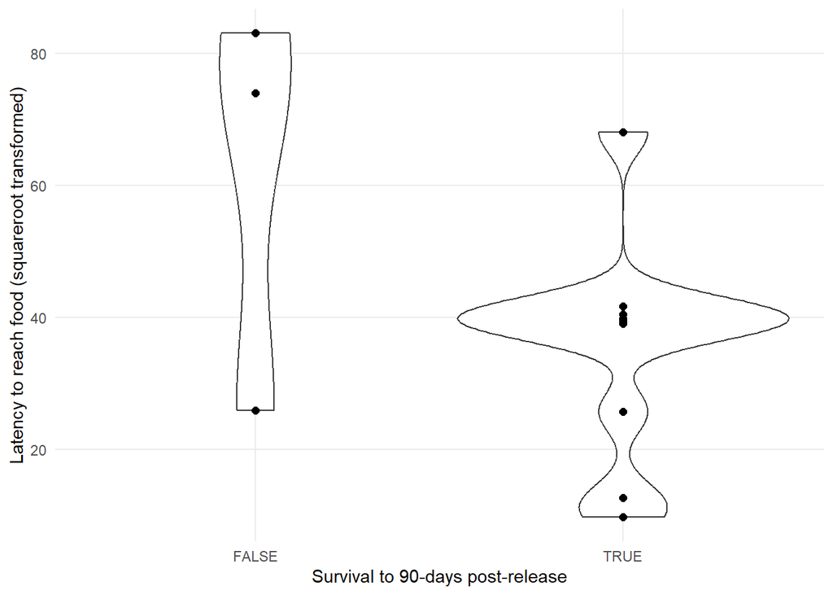

```r
# m2a: Does latency to reach food predict survival to 90 days?
## Violin plot
ggplot(data, aes(x= to_90, y =sqrt(latency), group=to_90))+
  geom_violin()+
  geom_point(size = 2)+
  labs(x= "Survival to 90-days post-release",
       y = "Latency to reach food (squareroot transformed)")+
  theme_minimal()+
  theme(panel.grid.minor = element_blank())+
  scale_x_continuous(breaks = c(0,1), labels = c(FALSE, TRUE))
```

```r
## Logistic regression with binomial family
m2a <- glm(to_90 ~ scale(sqrt(latency)),
           data = data,
           family = binomial())

summary(m2a)
```

```
##
## Call:
## glm(formula = to_90 ~ scale(sqrt(latency)), family = binomial(),
##     data = data)
##
## Coefficients:
##                      Estimate Std. Error z value Pr(>|z|)
## (Intercept)            1.7159     0.8761   1.959   0.0502 .
## scale(sqrt(latency))  -1.3820     0.8297  -1.666   0.0958 .
## ---
## Signif. codes:  0 '***' 0.001 '**' 0.01 '*' 0.05 '.' 0.1 ' ' 1
##
## (Dispersion parameter for binomial family taken to be 1)
##
##     Null deviance: 14.548  on 13  degrees of freedom
## Residual deviance: 10.969  on 12  degrees of freedom
## AIC: 14.969
##
## Number of Fisher Scoring iterations: 5
```

```r
# Survival probability
exp(coef(m2a))
```

```
##          (Intercept) scale(sqrt(latency))
##            5.5614031            0.2510837
```

Only three birds (21%) died in the period to 90-days post-release. There is weak evidence (i.e. marginally significant prediction) that shorter latency periods predict survival.

Model performance is imperfect, with non-normally distributed residuals. Given the management needs to balance risk and uncertainty during translocation, I would use this imperfect information to inform the translocation approach until better information can be gathered for adaptive management. Since lower latency *might* inform survival, and we want to reduce unnecessary mortality, this is a useful management tool.

Next, we looked at the effect of latency on survival to 1-year post-release.

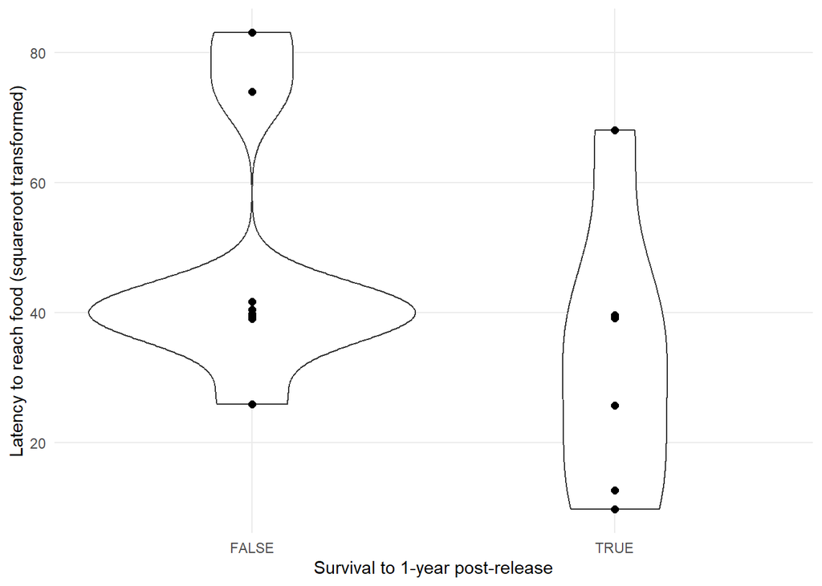

```r
# m2b: Does latency to reach food predict survival? To 360 days.
## Violin plot
ggplot(data, aes(x= to_360, y=sqrt(latency), group=to_360))+
  geom_violin()+
  geom_point(size = 2)+
  labs(x= "Survival to 1-year post-release",
       y = "Latency to reach food (squareroot transformed)")+
  theme_minimal()+
  theme(panel.grid.minor = element_blank())+
  scale_x_continuous(breaks = c(0,1), labels = c(FALSE, TRUE))
```

```r
## Logistic regression with binomial family
m2b <- glm(to_360 ~ scale(sqrt(latency)),
           data = data,
           family = binomial())

summary(m2b)
```

```
##
## Call:
## glm(formula = to_360 ~ scale(sqrt(latency)), family = binomial(),
##     data = data)
##
## Coefficients:
##                      Estimate Std. Error z value Pr(>|z|)
## (Intercept)           -0.3657     0.5958  -0.614    0.539
## scale(sqrt(latency))  -0.9462     0.7372  -1.284    0.199
##
## (Dispersion parameter for binomial family taken to be 1)
##
##     Null deviance: 19.121  on 13  degrees of freedom
## Residual deviance: 16.977  on 12  degrees of freedom
## AIC: 20.977
##
## Number of Fisher Scoring iterations: 3
```

Just under half of the birds (42%, n = 6) survived to the 1-year post-release period. The chance of survival increases with decreasing latency values. However, unlike for 90-days, the effect is not significant. This could indicate that latency has a more immediate impact on short-term survival but less influence on long-term survival.

Potentially, whatever behavioural traits are related to latency (perhaps risk:reward trade-off or drive for food) only relates to survival in the period immediately following release. Perhaps this is due to the drive to find food resources during establishment, but this effect does not impact long-term survival which is (likely) more related to anti-predation traits, rather than resource-related traits.

This highlights the importance of sampling period and the different drives of survival in the short and long term post-release.

### m3 Handling response and survival

Since handling score is categorical, we’ll use ANOVA and chi-squared to compare frequencies.

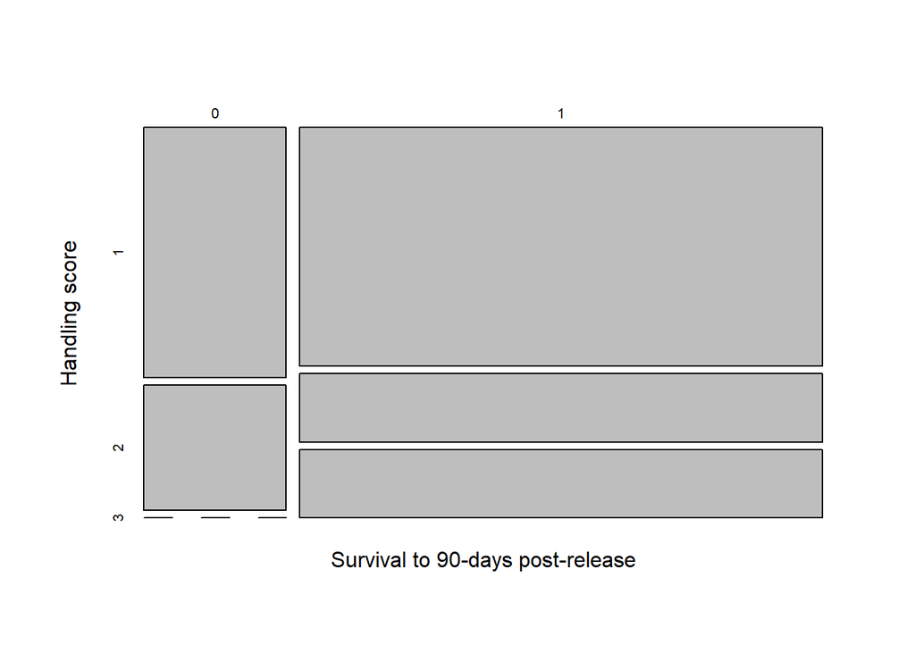

```r
# m3a: Does handling predict survival to 90 days?
## Mosaic plot
mosaicplot(table(data$to_90, data$score),
           main = NULL,
           xlab = "Survival to 90-days post-release",
           ylab = "Handling score")
```

```r
## Chisq test
chisq.test(table(data$to_90, data$score))
```

```
##
##  Pearson's Chi-squared test
##
## data:  table(data$to_90, data$score)
## X-squared = 0.80135, df = 2, p-value = 0.6699
```

```r
## Logistic regression with binomial family
m3a <- glm(to_90 ~ score,
           data = data,
           family = binomial())

summary(m3a)
```

```
##
## Call:
## glm(formula = to_90 ~ score, family = binomial(), data = data)
##
## Coefficients:
##             Estimate Std. Error z value Pr(>|z|)
## (Intercept)   0.6578     1.5419   0.427    0.670
## score         0.4478     1.0211   0.439    0.661
##
## (Dispersion parameter for binomial family taken to be 1)
##
##     Null deviance: 14.548  on 13  degrees of freedom
## Residual deviance: 14.335  on 12  degrees of freedom
## AIC: 18.335
##
## Number of Fisher Scoring iterations: 4
```

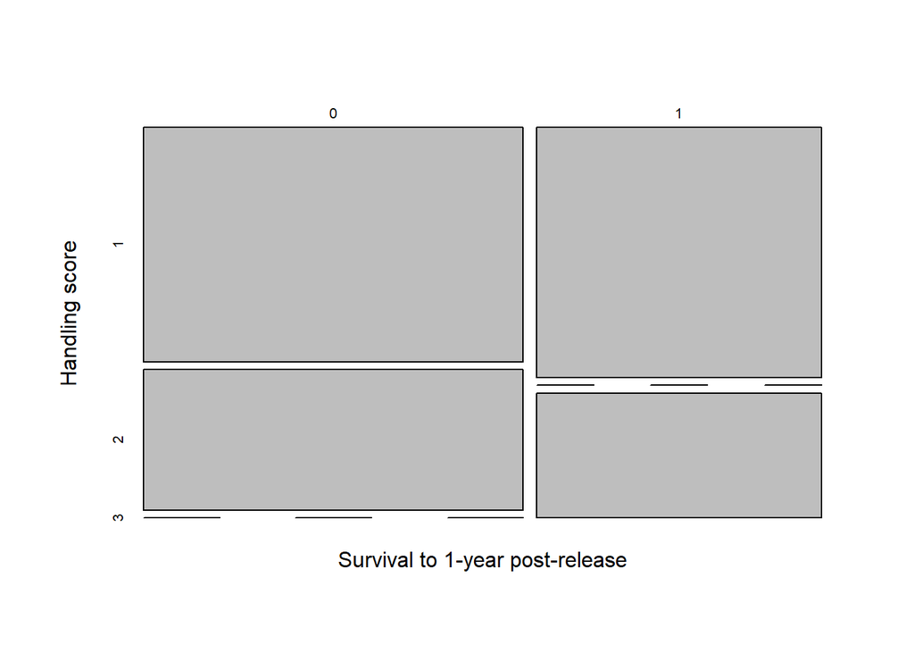

```r
# m3b: Does handling predict survival to 1 year?
## Mosaic plot
mosaicplot(table(data$to_360, data$score),
           main = NULL,
           xlab = "Survival to 1-year post-release",
           ylab = "Handling score")
```

```r
## Chisq test
chisq.test(table(data$to_360, data$score))
```

```
##
##  Pearson's Chi-squared test
##
## data:  table(data$to_360, data$score)
## X-squared = 4.9259, df = 2, p-value = 0.08518
```

```r
## Logistic regression with binomial family
m3b <- glm(to_360 ~ score,
           data = data,
           family = binomial())

summary(m3b)
```

```
##
## Call:
## glm(formula = to_360 ~ score, family = binomial(), data = data)
##
## Coefficients:
##             Estimate Std. Error z value Pr(>|z|)
## (Intercept)  -1.1138     1.2660  -0.880    0.379
## score         0.5469     0.7544   0.725    0.468
##
## (Dispersion parameter for binomial family taken to be 1)
##
##     Null deviance: 19.121  on 13  degrees of freedom
## Residual deviance: 18.579  on 12  degrees of freedom
## AIC: 22.579
##
## Number of Fisher Scoring iterations: 4
```

While there is no evidence of a relationship between handling score and survival to 90-days, there is weak evidence of a relationship to 1-year.

Some interesting observations:

1. Both birds with a handling score of 3 survived.
2. No birds with a handling score of 2 survived.

Perhaps an intermediate strategy is sub-optimal i.e., it’s better to either commit to full camouflage or full flight, not the middle ground. Perhaps the middle ground is evidence of habituation, since both scores 1 and 3 can be considered a predator-response behaviour (flight or camouflage).

Interestingly, the persistence for score 2 individuals is pretty long (195 & 308 days) - which contradicts my earlier thoughts about score 2 being maladaptive.

Overall, there is weak evidence that handling score predicts persistence. In the context of adaptive management (the same as for the latency score), I would use this information to inform management until better information can be gathered. That is, preferentially release score 3 birds when risk and uncertainty are high. I would not release score 2 birds during a pilot study, but perhaps they can be used later in a reintroduction program.

### m4 Weight and survival

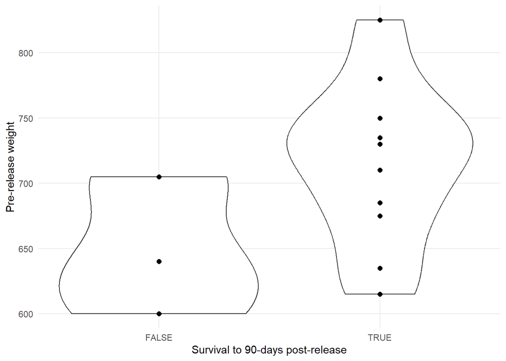

```r
# m4a: Does weight predict survival to 90 days?
## Violin plot
ggplot(data, aes(x= to_90, y=weight, group=to_90))+
  geom_violin()+
  geom_point(size = 2)+
  labs(x= "Survival to 90-days post-release",
       y = "Pre-release weight")+
  theme_minimal()+
  theme(panel.grid.minor = element_blank())+
  scale_x_continuous(breaks = c(0,1), labels = c(FALSE, TRUE))
```

```r
## Logistic regression with binomial family
m4a <- glm(to_90 ~ scale(weight),
           data = data,
           family = binomial())
summary(m4a)
```

```
##
## Call:
## glm(formula = to_90 ~ scale(weight), family = binomial(), data = data)
##
## Coefficients:
##               Estimate Std. Error z value Pr(>|z|)
## (Intercept)     1.7958     0.9450    1.90   0.0574 .
## scale(weight)   1.4730     0.9756    1.51   0.1311
## ---
## Signif. codes:  0 '***' 0.001 '**' 0.01 '*' 0.05 '.' 0.1 ' ' 1
##
## (Dispersion parameter for binomial family taken to be 1)
##
##     Null deviance: 14.548  on 13  degrees of freedom
## Residual deviance: 11.351  on 12  degrees of freedom
## AIC: 15.351
##
## Number of Fisher Scoring iterations: 5
```

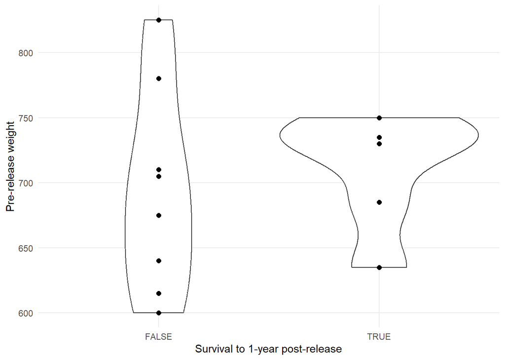

```r
# m4b: Does weight predict survival to 1 year?
## Violin plot
ggplot(data, aes(x= to_360, y=weight, group=to_360))+
  geom_violin()+
  geom_point(size = 2)+
  labs(x= "Survival to 1-year post-release",
       y = "Pre-release weight")+
  theme_minimal()+
  theme(panel.grid.minor = element_blank())+
  scale_x_continuous(breaks = c(0,1), labels = c(FALSE, TRUE))
```

```r
## Logistic regression with binomial family
m4b <- glm(to_360 ~ scale(weight),
           data = data,
           family = binomial())
summary(m4b)
```

```
##
## Call:
## glm(formula = to_360 ~ scale(weight), family = binomial(), data = data)
##
## Coefficients:
##               Estimate Std. Error z value Pr(>|z|)
## (Intercept)    -0.2936     0.5461  -0.538    0.591
## scale(weight)   0.3040     0.5730   0.530    0.596
##
## (Dispersion parameter for binomial family taken to be 1)
##
##     Null deviance: 19.121  on 13  degrees of freedom
## Residual deviance: 18.834  on 12  degrees of freedom
## AIC: 22.834
##
## Number of Fisher Scoring iterations: 4
```

No effect of weight on survival.

### m5 Sex and survival

A predictor for survival to 1-year was sex I investigate this separately here.

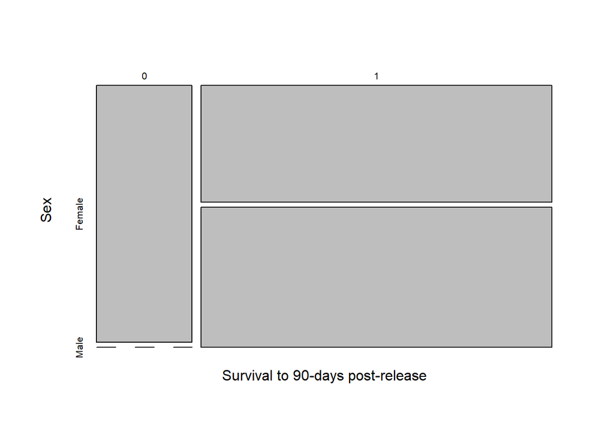

```r
# m5a: Does sex predict survival? To 90 days.
## Mosaic plot
mosaicplot(table(data$to_90, data$sex),
           main = NULL,
           xlab = "Survival to 90-days post-release",
           ylab = "Sex")
```

```r
chisq.test(table(data$to_90, data$sex))
```

```
##
##  Pearson's Chi-squared test with Yates' continuity correction
##
## data:  table(data$to_90, data$sex)
## X-squared = 1.0694, df = 1, p-value = 0.3011
```

```r
## Logistic regression with binomial family
m5a <- glm(to_90 ~ sex,
           data = data,
           family = binomial())

summary(m5a)
```

```
##
## Call:
## glm(formula = to_90 ~ sex, family = binomial(), data = data)
##
## Coefficients:
##              Estimate Std. Error z value Pr(>|z|)
## (Intercept)    0.5108     0.7303   0.699    0.484
## sexMale       19.0552  4390.3075   0.004    0.997
##
## (Dispersion parameter for binomial family taken to be 1)
##
##     Null deviance: 14.548  on 13  degrees of freedom
## Residual deviance: 10.585  on 12  degrees of freedom
## AIC: 14.585
##
## Number of Fisher Scoring iterations: 18
```

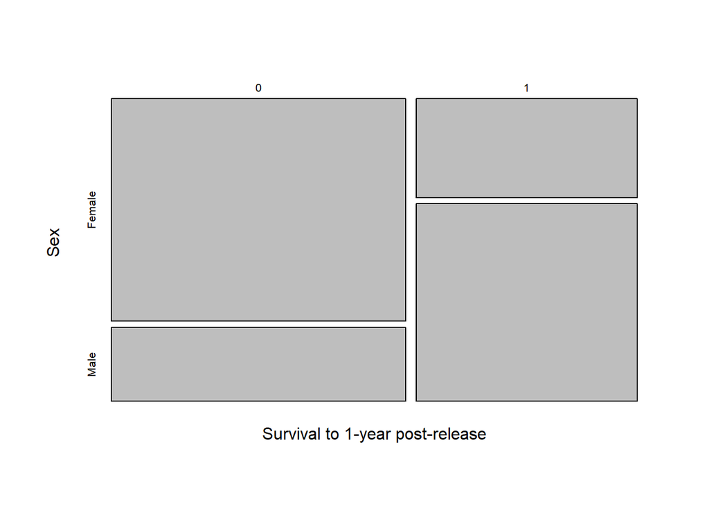

```r
# m5b: Does sex predict survival? To 1 year.
## Mosaic plot
mosaicplot(table(data$to_360, data$sex),
           main = NULL,
           xlab = "Survival to 1-year post-release",
           ylab = "Sex")
```

```r
chisq.test(table(data$to_360, data$sex))
```

```
##
##  Pearson's Chi-squared test with Yates' continuity correction
##
## data:  table(data$to_360, data$sex)
## X-squared = 1.0269, df = 1, p-value = 0.3109
```

```r
## Logistic regression with binomial family
m5b <- glm(to_360 ~ sex,
           data = data,
           family = binomial())

summary(m5b)
```

```
##
## Call:
## glm(formula = to_360 ~ sex, family = binomial(), data = data)
##
## Coefficients:
##             Estimate Std. Error z value Pr(>|z|)
## (Intercept)  -1.0986     0.8165  -1.346    0.178
## sexMale       1.7918     1.1902   1.505    0.132
##
## (Dispersion parameter for binomial family taken to be 1)
##
##     Null deviance: 19.121  on 13  degrees of freedom
## Residual deviance: 16.636  on 12  degrees of freedom
## AIC: 20.636
##
## Number of Fisher Scoring iterations: 4
```

Sex did not predict survival in either time period. The issue is there are only 2 males not surviving to 360 and none not surviving to 90 days. There isn’t enough predictive power. But it is interesting to mention. I wonder if sex is coming up as important because the males are bigger and bigger birds are surviving better?

### Comparison

Here I compare all the models on AICc (for small sample size).

```r
# Comparison for 90 day period
AICc(m1a, m2a, m3a, m4a, m5a)
```

```
##     df     AICc
## m1a  2 19.41236
## m2a  2 16.05967
## m3a  2 19.42546
## m4a  2 16.44220
## m5a  2 15.67592
```

```r
# Comparison for 1 year period
AICc(m1b, m2b, m3b, m4b, m5b)
```

```
##     df     AICc
## m1b  2 24.19847
## m2b  2 22.06753
## m3b  2 23.66948
## m4b  2 23.92442
## m5b  2 21.72644
```

The best model for the 90 day period was sex as the predictor, followed by latency and weight.

The best model for the 1 year was sex as the predictor, followed by latency and handling response.

## Survival analysis

Instead of looking at survival as a binary yes/no, we can also look at persistence as a continuous response. For this, I am using a survival analysis approach, since ‘persistence’ is a time-to-event response.

### m6 Survival plot

Start by looking at the overall survival probabilities for all birds.

```r
# Format data for Kaplan Meier Analysis - where death is TRUE i.e. 1
km <- data %>%
  mutate(time = persist,
         status = ifelse(to_360 == 0, 1, 0),
         sex = as.factor(sex),
         condition = as.factor(condition),
         score = as.factor(score)) %>%
  select(-c(persist, to_90, to_360))

# Fit a survival model
m6 <- survfit(Surv(time, status) ~ 1, km)

# Estimated survival probabilities
summary(m6, times = c(1,90, 180, 270, 360))
```

```
## Call: survfit(formula = Surv(time, status) ~ 1, data = km)
##
##  time n.risk n.event survival std.err lower 95% CI upper 95% CI
##     1     14       0    1.000   0.000        1.000        1.000
##    90     11       3    0.786   0.110        0.598        1.000
##   180      8       3    0.571   0.132        0.363        0.899
##   270      7       1    0.500   0.134        0.296        0.844
##   360      6       1    0.429   0.132        0.234        0.785
```

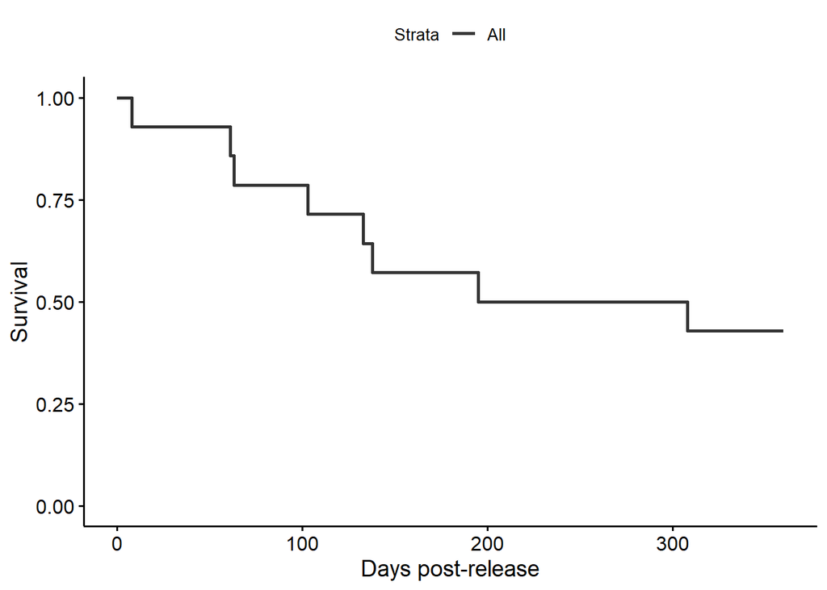

```r
# Kaplan Meyer Plot
ggsurvplot(m6, data = km, risk.table = FALSE,
           gtheme = theme_bw(),
           censor = FALSE,
           xlab = "Days post-release",
           ylab = "Survival",
           xlim = c(0,360),
           palette = "grey20",
           conf.int = FALSE)
```

The probability of survival to 1 year is 43% (upper CI = 78%, lower CI = 23%).

### m7 Handling response and persistence

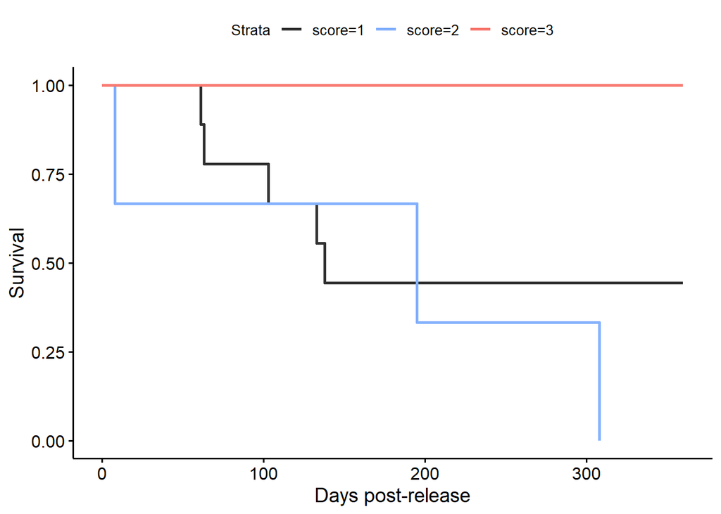

```r
# Fit a survival model with handling as the grouping variable
km7 <- survfit(Surv(time, status) ~ score, km)

# Kaplan Meyer Plot
ggsurvplot(km7, data = km, risk.table = FALSE,
           gtheme = theme_bw(),
           censor = FALSE,
           xlab = "Days post-release",
           ylab = "Survival",
           xlim = c(0,360),
           palette = c("grey20", "#83b0fc", "#f8766d"),
           conf.int = FALSE)
```

```r
# Test the difference between these survival curves
survdiff(Surv(time, status) ~ score, km)
```

```
## Call:
## survdiff(formula = Surv(time, status) ~ score, data = km)
##
##         N Observed Expected (O-E)^2/E (O-E)^2/V
## score=1 9        5     4.87   0.00374   0.00968
## score=2 3        3     1.53   1.40754   1.75423
## score=3 2        0     1.60   1.60312   2.03211
##
##  Chisq= 3  on 2 degrees of freedom, p= 0.2
```

```r
# Test as a Cox Proportional Hazard model
m7 <- coxph(Surv(time, status) ~ score, km)
summary(m7)
```

```
## Call:
## coxph(formula = Surv(time, status) ~ score, data = km)
##
##   n= 14, number of events= 8
##
##              coef  exp(coef)   se(coef)      z Pr(>|z|)
## score2  6.487e-01  1.913e+00  7.359e-01  0.882    0.378
## score3 -1.928e+01  4.251e-09  1.187e+04 -0.002    0.999
##
##        exp(coef) exp(-coef) lower .95 upper .95
## score2 1.913e+00  5.227e-01    0.4522     8.094
## score3 4.251e-09  2.352e+08    0.0000       Inf
##
## Concordance= 0.651  (se = 0.087 )
## Likelihood ratio test= 4.33  on 2 df,   p=0.1
## Wald test            = 0.78  on 2 df,   p=0.7
## Score (logrank) test = 3.04  on 2 df,   p=0.2
```

We have different survival curves for the 3 handling score groups, but overall the difference between the curves is not significant (model convergence problems due to low group sizes: only 2 individuals in score 3).

### m8 Sex and persistence

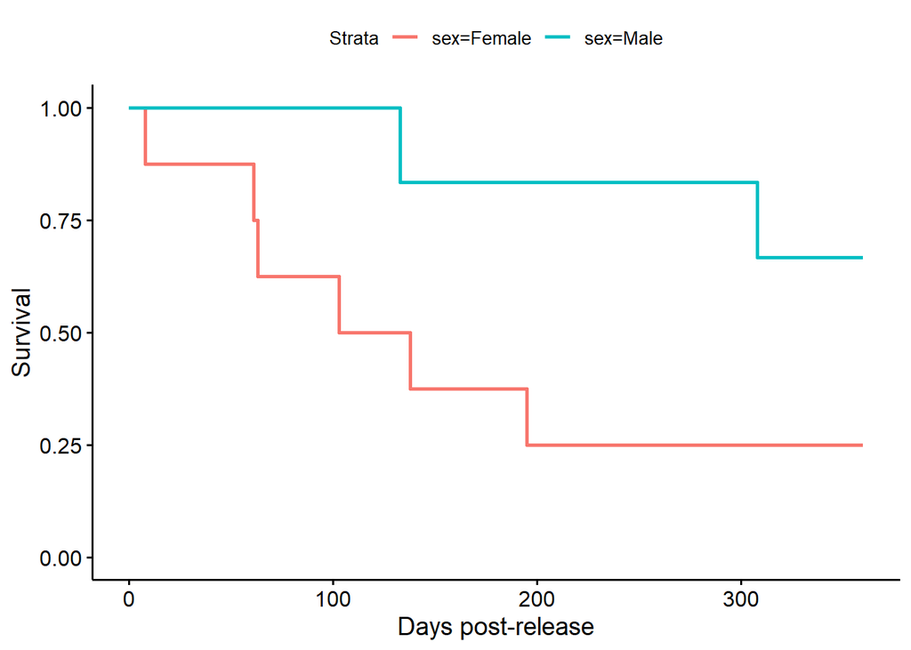

```r
# Fit a survival model with sex as the grouping variable
km8 <- survfit(Surv(time, status) ~ sex, km)

# Kaplan Meyer Plot
ggsurvplot(km8, data = km, risk.table = FALSE,
           gtheme = theme_bw(),
           censor = FALSE,
           xlab = "Days post-release",
           ylab = "Survival",
           xlim = c(0,360),
           conf.int = FALSE)
```

```r
# Test the difference between these survival curves
survdiff(Surv(time, status) ~ sex, km)
```

```
## Call:
## survdiff(formula = Surv(time, status) ~ sex, data = km)
##
##            N Observed Expected (O-E)^2/E (O-E)^2/V
## sex=Female 8        6     3.57      1.65      3.08
## sex=Male   6        2     4.43      1.33      3.08
##
##  Chisq= 3.1  on 1 degrees of freedom, p= 0.08
```

```r
# Test as a Cox Proportional Hazard model
m8 <- coxph(Surv(time, status) ~ sex, km)
summary(m8)
```

```
## Call:
## coxph(formula = Surv(time, status) ~ sex, data = km)
##
##   n= 14, number of events= 8
##
##            coef exp(coef) se(coef)      z Pr(>|z|)
## sexMale -1.3551    0.2579   0.8271 -1.638    0.101
##
##         exp(coef) exp(-coef) lower .95 upper .95
## sexMale    0.2579      3.877   0.05099     1.305
##
## Concordance= 0.684  (se = 0.071 )
## Likelihood ratio test= 3.15  on 1 df,   p=0.08
## Wald test            = 2.68  on 1 df,   p=0.1
## Score (logrank) test = 3.08  on 1 df,   p=0.08
```

### m9 Condition and persistence

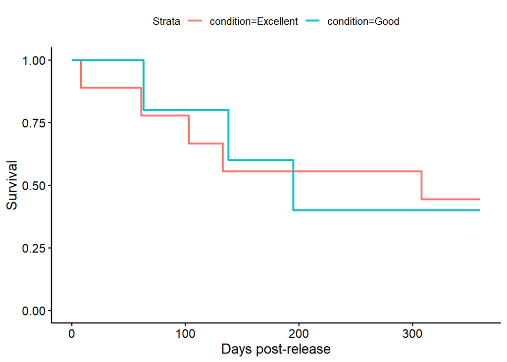

```r
# Fit a survival model with condition as the grouping variable
km9 <- survfit(Surv(time, status) ~ condition, km)

# Kaplan Meyer Plot
ggsurvplot(km9, data = km, risk.table = FALSE,
           gtheme = theme_bw(),
           censor = FALSE,
           xlab = "Days post-release",
           ylab = "Survival",
           xlim = c(0,360),
           conf.int = FALSE)
```

```r
# Test the difference between these survival curves
survdiff(Surv(time, status) ~ condition, km)
```

```
## Call:
## survdiff(formula = Surv(time, status) ~ condition, data = km)
##
##                     N Observed Expected (O-E)^2/E (O-E)^2/V
## condition=Excellent 9        5     4.97  0.000149  0.000397
## condition=Good      5        3     3.03  0.000245  0.000397
##
##  Chisq= 0  on 1 degrees of freedom, p= 1
```

```r
# Test as a Cox Proportional Hazard model
m9 <- coxph(Surv(time, status) ~ condition, km)
summary(m9)
```

```
## Call:
## coxph(formula = Surv(time, status) ~ condition, data = km)
##
##   n= 14, number of events= 8
##
##                   coef exp(coef) se(coef)     z Pr(>|z|)
## conditionGood -0.01461   0.98549  0.73333 -0.02    0.984
##
##               exp(coef) exp(-coef) lower .95 upper .95
## conditionGood    0.9855      1.015    0.2341     4.148
##
## Concordance= 0.52  (se = 0.088 )
## Likelihood ratio test= 0  on 1 df,   p=1
## Wald test            = 0  on 1 df,   p=1
## Score (logrank) test = 0  on 1 df,   p=1
```

No difference between good and excellent condition.

The last grouping variable is age but can’t use this since only one individual in age 1.

### m10 Latency and persistence

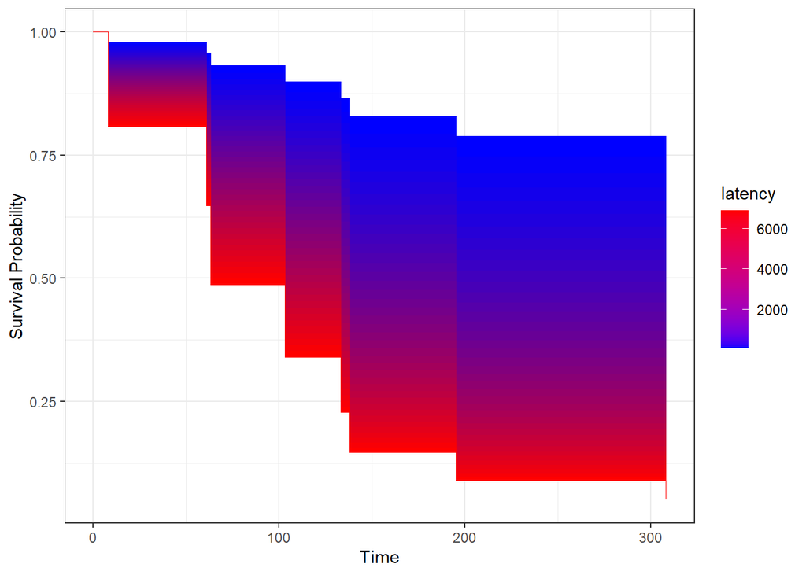

```r
# Fit a survival model with latency as the continuous variable
m10 <- coxph(Surv(time, status) ~ sqrt(latency), km, x= TRUE)

# Plot the survival area
plot_surv_area(model = m10, data = km,
               time = "time", status = "status", variable = "latency", group = NULL)
```

```r
# Test effect of latency - log rank test
summary(m10)
```

```
## Call:
## coxph(formula = Surv(time, status) ~ sqrt(latency), data = km,
##     x = TRUE)
##
##   n= 14, number of events= 8
##
##                  coef exp(coef) se(coef)     z Pr(>|z|)
## sqrt(latency) 0.03163   1.03214  0.01897 1.667   0.0955 .
## ---
## Signif. codes:  0 '***' 0.001 '**' 0.01 '*' 0.05 '.' 0.1 ' ' 1
##
##               exp(coef) exp(-coef) lower .95 upper .95
## sqrt(latency)     1.032     0.9689    0.9945     1.071
##
## Concordance= 0.711  (se = 0.124 )
## Likelihood ratio test= 2.76  on 1 df,   p=0.1
## Wald test            = 2.78  on 1 df,   p=0.1
## Score (logrank) test = 2.91  on 1 df,   p=0.09
```

Weak evidence for effect of latency (on the log rank test). Visually, shorter latency periods have higher survival likelihoods.

### m11 Alert behaviour and persistence

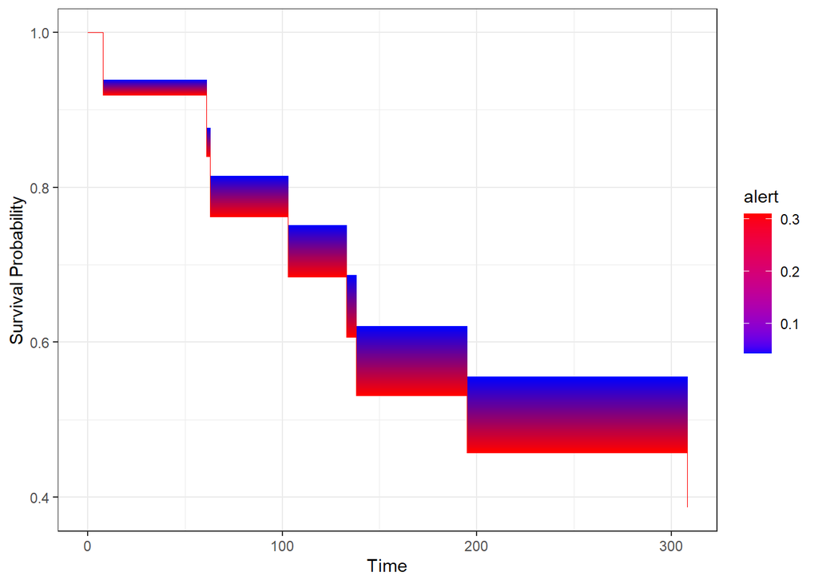

```r
# Fit a survival model with alert behaviour as the continuous variable
m11 <- coxph(Surv(time, status) ~ alert, km, x= TRUE)

# Plot the survival area
plot_surv_area(model = m11, data = km,
               time = "time", status = "status", variable = "alert", group = NULL)
```

```r
# Test effect of alert behaviour - log rank test
summary(m11)
```

```
## Call:
## coxph(formula = Surv(time, status) ~ alert, data = km, x = TRUE)
##
##   n= 14, number of events= 8
##
##        coef exp(coef) se(coef)     z Pr(>|z|)
## alert 1.064     2.899    4.171 0.255    0.799
##
##       exp(coef) exp(-coef) lower .95 upper .95
## alert     2.899      0.345 0.0008158     10299
##
## Concordance= 0.526  (se = 0.136 )
## Likelihood ratio test= 0.06  on 1 df,   p=0.8
## Wald test            = 0.07  on 1 df,   p=0.8
## Score (logrank) test = 0.07  on 1 df,   p=0.8
```

No effect of alertness on survival.

### m12 Weight and persistence

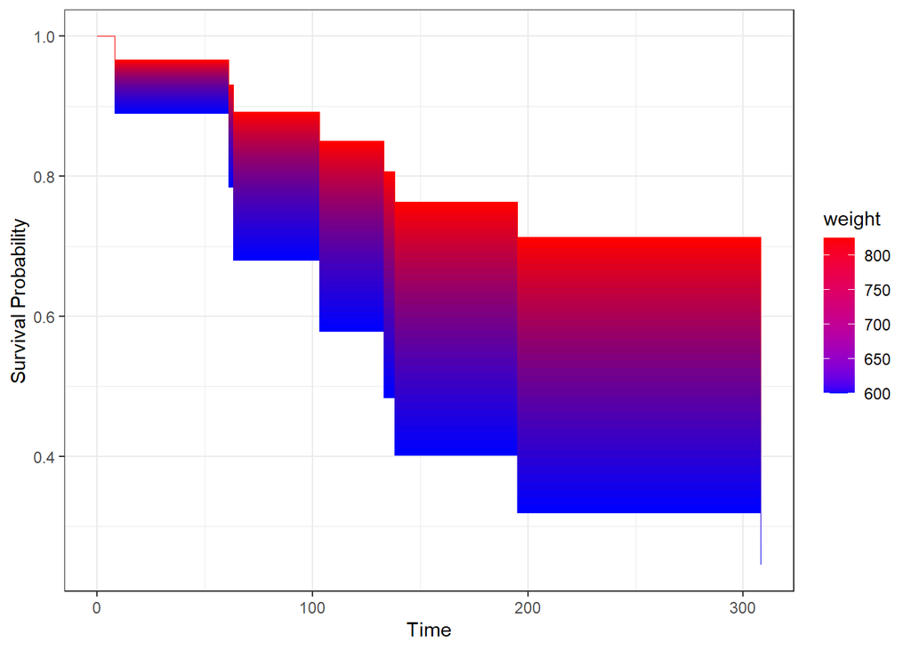

```r
# m12 a survival model with weight as the continuous variable
m12 <- coxph(Surv(time, status) ~ weight, km, x= TRUE)

# Plot the survival area
plot_surv_area(model = m12, data = km,
               time = "time", status = "status", variable = "weight", group = NULL)
```

```r
# Test effect of weight - log rank test
summary(m12)
```

```
## Call:
## coxph(formula = Surv(time, status) ~ weight, data = km, x = TRUE)
##
##   n= 14, number of events= 8
##
##             coef exp(coef)  se(coef)     z Pr(>|z|)
## weight -0.005405  0.994609  0.006357 -0.85    0.395
##
##        exp(coef) exp(-coef) lower .95 upper .95
## weight    0.9946      1.005    0.9823     1.007
##
## Concordance= 0.632  (se = 0.1 )
## Likelihood ratio test= 0.73  on 1 df,   p=0.4
## Wald test            = 0.72  on 1 df,   p=0.4
## Score (logrank) test = 0.73  on 1 df,   p=0.4
```

Not significant - but the heavier birds survive better.

What if we combine sex and weight?